# Fordgobike 2019-02 dataset Data Exploration

## by Divya Prasanth P

## Investigation Overview

> I intend to investigate how bike ride duration is associated with day of the week, hour of the day, rider's gender, age and user_type

## Dataset Overview

> The fordgobike-tripdata dataset provides information on each bike ride made in the fordgobike program from February 1st, 2019 to March 1st, 2019. It contains information such as starting station details, ending station details, starting time, ending time, duration of the ride and information about the rider such as rider's gender, birth_year, program subscription type for about 183K rides made. There are about 183k rows and 16 columns.

## Correlation Grid

> The following grid and plot shows that there is very less correlation between age and duration. Hence age is not considered further for analysis

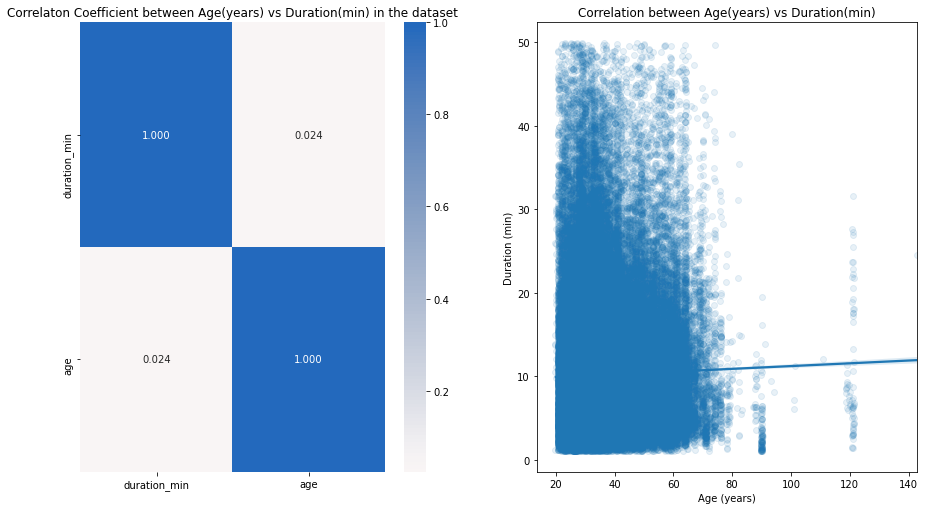

## Duration vs Gender

> The male population is significantly larger than the female and other population. However the median duration of female is higher than the other categories.

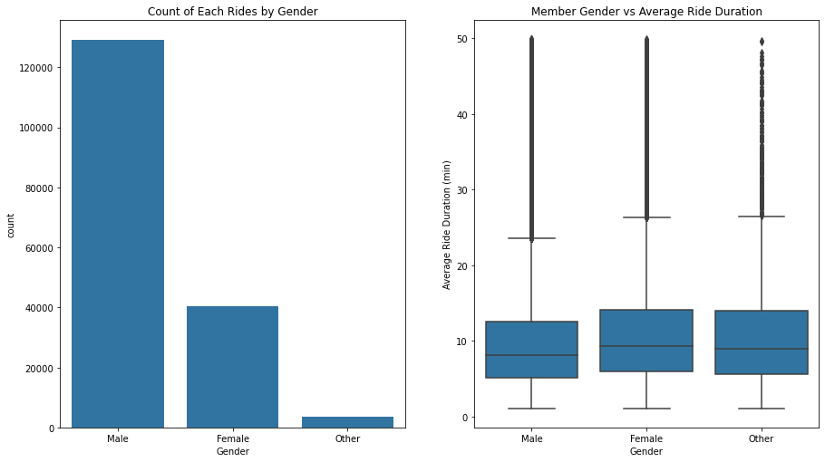